# Introduction to EGRET Confidence Intervals

Robert M. Hirsch, Laura A. De Cicco

17 April, 2025

# Introduction

This package **EGRETci** implements a set of approaches to the analysis of uncertainty associated with WRTDS trend analysis as implemented in the **EGRET** package. The various functions included here are all discussed in the [*A bootstrap method for estimating uncertainty of water quality trends* Hirsch, Archfield, and De Cicco, 2015](https://doi.org/10.1016/j.envsoft.2015.07.017)

The **EGRETci** package is designed for interactive or batch use. Instructions for both are included here in the vignette. The package allows users to set the Period of Analysis, and various smoothing parameters for WRTDS. Users should consult the **EGRET** vignette for more background on those issues. For more extensive documentation refer to [EGRETci](http://doi-usgs.github.io/EGRETci/)

## Required Data Frames

| Data Frame | Column | Definition |
| --- | --- | --- |
| bootOut | rejectC | Reject Ho, (no trend in concentration), TRUE or FALSE |
|  | pValC | two-sided p-value for no trend in concentration |
|  | estC | standard WRTDS estimate of change from starting year to ending year in mg/L |
|  | lowC90 | Lower confidence limit (90%) on concentration trend |
|  | upC90 | Upper confidence limit (90%) on concentration trend |
|  | lowC50 | Lower confidence limit (50%) on concentration trend |
|  | upC50 | Upper confidence limit (50%) on concentration trend |
|  | lowC95 | Lower confidence limit (95%) on concentration trend |
|  | upC95 | Upper confidence limit (95%) on concentration trend |
|  | likeCUp | Likelihood that trend in concentration is upwards |
|  | likeCDown | Likelihood that trend in concentration is downwards |
|  | rejectF | Reject Ho, (no trend in flux), TRUE or FALSE |
|  | pValF | two-sided p-value for no trend in flux |
|  | estF | estimate of change from starting year to ending year, in 10<sup>6</sup> kg/yr |
|  | lowF90 | Lower confidence limit (90%) on flux trend |
|  | upF90 | Upper confidence limit (90%) on flux trend |
|  | lowF50 | Lower confidence limit (50%) on flux trend |
|  | upF50 | Upper confidence limit (50%) on flux trend |
|  | lowF95 | Lower confidence limit (95%) on flux trend |
|  | upF95 | Upper confidence limit (95%) on flux trend |
|  | likeFUp | Likelihood that trend in flux is upwards |
|  | likeFDown | Likelihood that trend in flux is downwards |
|  | baseConc | Estimated mean flow-normalized concentration for first year, in mg/L |
|  | baseFlux | Estimated mean flow-normalized flux for start year, in 10<sup>6</sup> kg/yr |
|  | iBoot | The actual number of bootstrap replicates used |
| wordsOut |  | a vector of four character variables (self explanatory) |
| xConc |  | a vector of length iBoot, of the change in flow normalized concentration computed by each bootstrap replicate (mg/L) |
| xFlux |  | a vector of length iBoot, of the change in flow normalized flux computed by each bootstrap replicate (10<sup>6</sup> kg/yr) |
| pConc |  | a vector of length iBoot, of the change in flow normalized concentration computed from each bootstrap replicate expressed as % change |
| pFlux |  | a vector of length iBoot, of the change in flow normalized flux computed from each bootstrap replicate expressed as % change |

# WRTDS Bootstrap Test

The WBT (WRTDS Bootstrap Test) can be run interactively or in batch.

Regardless of which approach is used, if the user wishes to use any non-default values of the parameters for model estimation or period of analysis these need to be set up before running the code. For example:

If the period of analysis is to be anything other than a Water Year (paStart=10, paLong=12), the user must use the `setPA` function. For example if we want to do the analysis for the three months starting with April, the command would be `eList <- setPA(eList, paStart = 4, paLong = 3)`.

If the desired value of windowY was 10 rather than the default value of 7, then the command needed would be `eList$INFO$windowY <- 10`, similar commands can be used for windowQ, windowS, minNumObs, minNumUncen and edgeAdjust (see help page for `modelEstimation` in the **EGRET** package).

Once all of the parameters have been set (which requires no action by the user if the defaults are to be used) the set of commands to do a pairs analysis are:

```r
library(EGRET)
library(EGRETci)
eList <- Choptank_eList

year1 <- 1985
year2 <- 2009

pairOut <- EGRET::runPairs(eList,
                             year1, year2,
                             windowSide = 7)

# For good analysis, set nBoot to about 100
# For a quick check that things are working, set it much lower:
boot_pair_out <- runPairsBoot(eList, pairOut, nBoot = 100)
```

The output looks like this:

```
   Choptank River
   Inorganic nitrogen (nitrate and nitrite)
   Water Year

 Change estimates are for  2009  minus  1985

Should we reject Ho that Flow Normalized Concentration Trend = 0 ? Reject Ho
 best estimate of change in concentration is   0.377 mg/L
  Lower and Upper 90% CIs 0.2748546 0.4383584
 also 95% CIs 0.2517219 0.4588038
 and 50% CIs 0.3360355 0.4079827
 approximate two-sided p-value for Conc      0.02
* Note p-value should be considered to be < stated value
 Likelihood that Flow Normalized Concentration is trending up = 0.995  is trending down = 0.00495
* Note p-value should be considered to be < stated value

Should we reject Ho that Flow Normalized Flux Trend = 0 ? Reject Ho
 best estimate of change in flux is   0.0538 10^6 kg/year
  Lower and Upper 90% CIs 0.0367071 0.06235301
 also 95% CIs 0.03299696 0.0635553
 and 50% CIs 0.04764486 0.05776485
 approximate two-sided p-value for Flux      0.02
* Note p-value should be considered to be < stated value
 Likelihood that Flow Normalized Flux is trending up = 0.995  is trending down = 0.00495

 Upward trend in concentration is highly likely
 Upward trend in flux is highly likely
 Downward trend in concentration is highly unlikely
 Downward trend in flux is highly unlikely
```

Let’s run another example, where we assume that we want use the example data set Choptank_eList and have a PA of December, January, February and March, that we wanted to set windowY = 10 and minNumObs = 50, and all other smoothing parameters at their default values. And we want to run the trend analysis for 1990 to 2011, use a maximum of 50 replicates, and a block length of 200. The script would be:

```r
library(EGRET)
library(EGRETci)
eList <- Choptank_eList
eList <- setPA(eList, paStart = 12, paLong = 4)
eList$INFO$windowY <- 10
eList$INFO$minNumObs <- 50

year1 <- 1990
year2 <- 2011

pairOut <- EGRET::runPairs(eList,
                             year1, year2,
                             windowSide = 7)
```

```
##
##    Choptank River
##    Inorganic nitrogen (nitrate and nitrite)
##    Season Consisting of Dec Jan Feb Mar
##
##  Change estimates  2011  minus  1990
##
##  For concentration: total change is  0.175 mg/L
##  expressed as Percent Change is  +13.29 %
##
##  Concentration v. Q Trend Component  +15.36 %
##        Q Trend Component             -2.08 %
##
##
##  For flux: total change is  0.0276 million kg/year
##  expressed as Percent Change is  +12.56 %
##
##  Concentration v. Q Trend Component  +6.77 %
##        Q Trend Component             +5.79 %
##
##      TotalChange  CQTC    QTC  x10  x11  x20  x22
## Conc       0.175 0.203 -0.027 1.32 1.32 1.52 1.50
## Flux       0.028 0.015  0.013 0.22 0.22 0.23 0.25
```

```r
boot_pair_out <- runPairsBoot(eList, pairOut, nBoot = 50)
```

```
##
##    Choptank River
##    Inorganic nitrogen (nitrate and nitrite)
##    Season Consisting of Dec Jan Feb Mar
##
##  Change estimates are for  2011  minus  1990
##
## Should we reject Ho that Flow Normalized Concentration Trend = 0 ? Do Not Reject Ho
##  best estimate of change in concentration is   0.175 mg/L
##   Lower and Upper 90% CIs -0.1041711 0.2976591
##  also 95% CIs -0.1658517 0.3008164
##  and 50% CIs 0.08048021 0.2408267
##  approximate two-sided p-value for Conc      0.28
##  Likelihood that Flow Normalized Concentration is trending up = 0.853  is trending down = 0.147
##
## Should we reject Ho that Flow Normalized Flux Trend = 0 ? Do Not Reject Ho
##  best estimate of change in flux is   0.0276 10^6 kg/year
##   Lower and Upper 90% CIs -0.01300083 0.04795364
##  also 95% CIs -0.03004896 0.05121886
##  and 50% CIs 0.00558965 0.03765054
##  approximate two-sided p-value for Flux      0.34
##  Likelihood that Flow Normalized Flux is trending up = 0.833  is trending down = 0.167
##
##  Upward trend in concentration is likely
##  Upward trend in flux is likely
##  Downward trend in concentration is unlikely
##  Downward trend in flux is unlikely
```

## Histograms

The function `plotHistogramTrend` plots a histogram of all of the trend magnitudes (expressed in percentage change over the selected period) from the full set of replicates created by `runPairsBoot` or `runGroupsBoot`. These magnitudes are stored in the eBoot list. These histograms serve the purpose of providing a graphical impression of the central tendency and the uncertainty about the size of a trend. They can be used to help answer questions like: “How sure are we that the trend is positive?” or “How sure are we that the decrease is at least a 20% decrease over the period of interest?” The `plotHistogramTrend` function can produce histograms either for Flow Normalized Concentration or for Flow Normalized Flux.

When creating a histogram it is important to carefully determine what “bins” to use. In this plot it is a good idea to make sure that the plot covers a range of both negative and positive values even though it might be the case that the entire range of the trend magnitudes is positive (or negative). The function is set up so that it defaults to setting up 10 bins and the bins are set to cover the full range of the magnitudes and at least cover magnitudes as low as -10% and as high as +10%. The bins are set up based on a minimum value (xMin), a maximum value (xMax), and a step size (xStep). The defaults used in an initial run can simply leave out these three arguments and will produce a plot. This first plot would not be suitable for publication or display, but is intended to guide the analyst to set these three arguments to produce a suitable plot.

Note that the plots always show a vertical solid line at 0% trend, simply as a point of reference for the “no trend” result. They also show a dashed vertical line at the value of the ordinary WRTDS estimate of the trend magnitude in percent. This vertical line fall near the median value for all the bootstrap replicates.

This initial run will give the analyst the basic information needed to set up a good set of values for xMin, xMax and xStep.

[figure not shown]

```r
library(EGRET)
library(EGRETci)

#Concentration an initial run:
plotHistogramTrend(eList = eList, eBoot = boot_pair_out,
                   xMin = -15, xMax = 35, xStep = 5)
```

```r
#Flux an initial run:
plotHistogramTrend(eList = eList, eBoot = boot_pair_out,
                   xMin = -15, xMax = 35, xStep = 5,
                   flux = TRUE)
```

Having seen these initial versions of the plot one can run the functions again with a set of arguments that will produce a plot that is suitable for presentation or publication.

Alternatively, the two plots can be shown side-by-side using a workflow. Use the `par` function to set up both functions to plot side-by-side:

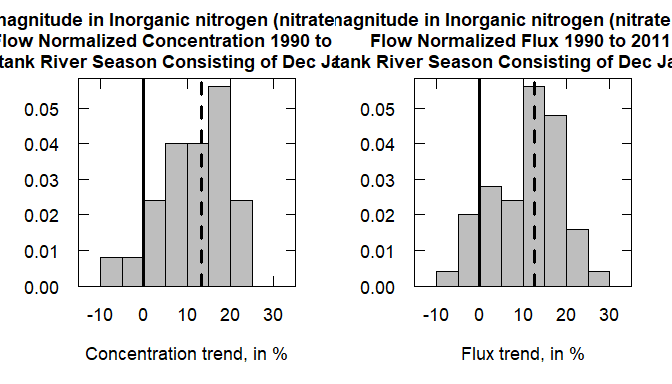

```r
par(mfrow=c(1,2))
#Concentration, presentation version:
plotHistogramTrend(eList = eList, eBoot = boot_pair_out,
                   xMin = -15, xMax = 35, xStep = 5,
                   flux = FALSE)

#Flux, presentation version:
plotHistogramTrend(eList = eList, eBoot = boot_pair_out,
                   xMin = -15, xMax = 35, xStep = 5,
                   flux = TRUE)
```

```r
# To return to figures printing in 1 row, 1 columns:
par(mfrow=c(1,1))
```

Or:

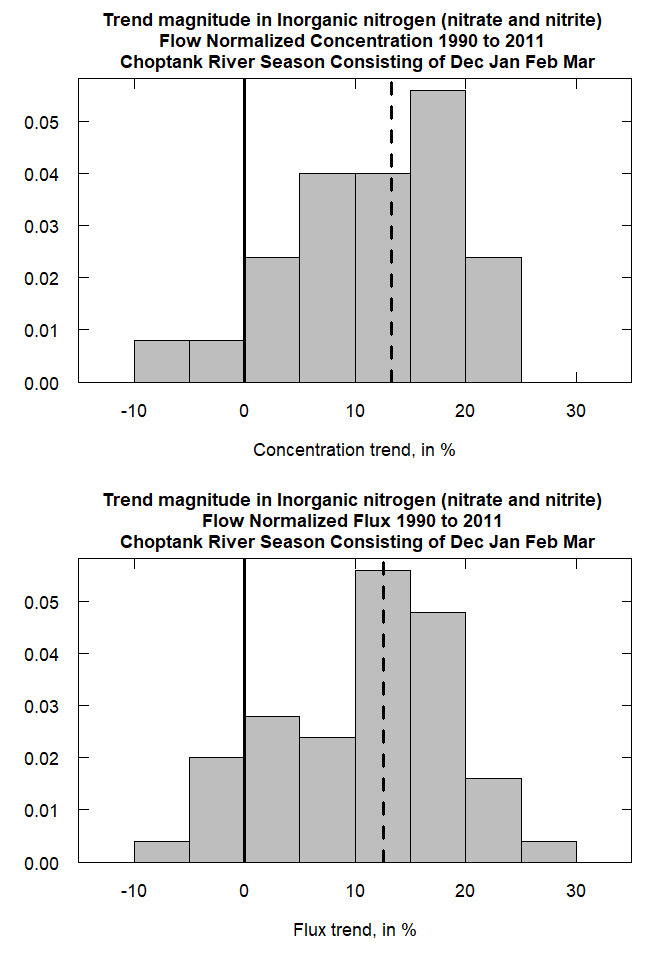

```r
par(mfrow=c(2,1))
#Concentration, presentation version:
plotHistogramTrend(eList = eList, eBoot = boot_pair_out,
                   xMin = -15, xMax = 35, xStep = 5,
                   flux = FALSE)

#Flux, presentation version:
plotHistogramTrend(eList = eList, eBoot = boot_pair_out,
                   xMin = -15, xMax = 35, xStep = 5,
                   flux = TRUE)
```

```r
# To return to figures printing in 1 row, 1 columns:
par(mfrow=c(1,1))
```

# Confidence Bands

## Introduction

The purpose here is to produce a graphic that looks just like those produced by `plotConcHist` or `plotFluxHist` but with the addition of confidence bands around the flow-normalized histories. There are two versions of the workflow for confidence bands, the first just uses a single computer core which means it takes a long time to run (jobs can take an hour or more), but it is simple to run. It uses the function `ciCalculations` and can be run interactively or in batch. Two scripts for that are provided below. It is best done in the Terminal or some other window, rather than in the console. If run in the console it will make it impossible for other work in R to take place while the job is running. The second way it can be done is using parallel computing in R. A script for that purpose is provided. It does require three extra packages be installed (**foreach**, **doParallel**, and **iterators**). It is also best to run this in the Terminal, because if it is run in the console, no other R work can be done while it is running.

## Preliminary Steps

Regardless of the approach (single core or parallel) being taken to the computations, the user needs to set up any non-default values of the parameters for model estimation and period of analysis. For example:

If the period of analysis is to be anything other than a Water Year (paStart=10, paLong=12), the user must use the `setPA` function. For example if we want to do the analysis for the three months starting with April, the command would be `eList <- setPA(eList, paStart = 4, paLong = 3)`.

If the desired value of windowY was 10 rather than the default value of 7, then the command needed would be `eList$INFO$windowY <- 10`, similar commands can be used for windowQ, windowS, minNumObs, minNumUncen and edgeAdjust (see help page for `modelEstimation`).

It is imperative that the standard WRTDS trend analysis be run prior to running the code for the confidence bands. If the user has made changes in smoothing parameters or modified the data in any way since the last time `modelEstimation` was run, the standard running of `modelEstimation` must be done and the output saved as `eList`. The commands would be:

```r
eList <- modelEstimation(eList)
```

## Simple Workflow

This example workflow assumes that we use the default values (nBoot = 100) for all of the model parameters and PA and uses the example eList provided in the package. Remember, this is a very long-running process:

```r
library(EGRET)
library(EGRETci)

eList <- Choptank_eList

CIAnnualResults <- ciCalculations(eList)

save(eList,CIAnnualResults, file="CIAnnualResults.RData")
```

To run the `ciCalculations` function in batch mode, the only difference is that additional arguments are specified in the call to the function. For example the call to `ciCalculations` might read as follows:

```r
CIAnnualResults <- ciCalculations(eList, nBoot = 100, blockLength = 200, widthCI = 90)
```

As long as all required arguments (nBoot, blockLength, and widthCI) are specified there will be no interaction needed.

## Parallel Computing

Taking advantage of the **foreach** package to do parallel computing:

```r
library(foreach)
library(doParallel)
library(iterators)
library(EGRET)
library(EGRETci)

eList <- Choptank_eList
eList <- modelEstimation(eList)

nBoot <- 100
blockLength <- 200
coreOut <- 1 #Number of cores to leave out of processing tasks

widthCI <- 90
ciLower <- (50-(widthCI/2))/100
ciUpper <- (50+(widthCI/2))/100
probs <- c(ciLower,ciUpper)

nCores <- detectCores() - coreOut
cl <- makeCluster(nCores)
registerDoParallel(cl)
repAnnual <- foreach(n = 1:nBoot,.packages=c('EGRETci')) %dopar% {
   annualResults <- bootAnnual(eList,
                               blockLength,
                               startSeed = n)
}
stopCluster(cl)

# save(repAnnual, file="repAnnual.RData")

CIAnnualResults <- ciBands(eList, repAnnual, probs)
save(eList,CIAnnualResults, file="CIAnnualResults.RData")
```

## CI Result Plots

Regardless of the way that the computations are done the outputs that are needed for the graphics are contained in eList and CIAnnualResults (which in either script will end up in a file called CIAnnualResults.RData). Once that file is loaded the graphics can be produced using the functions `plotConcHistBoot` and `plotFluxHistBoot`. Each of these functions only require two arguments (eList and CIAnnualResults). However, the user can specify a number of other arguments. These other arguments are the same ones used in the `plotConcHist` and `plotFluxHist` functions in the base **EGRET** package.

The user can also view a table of the confidence interval values shown in these graphics simply by using the command `CIAnnualResults` (fluxes will be in units if kg/day).

Here is a script for producing these graphics, using the example eList and CIAnnualResults data frames included in the package.

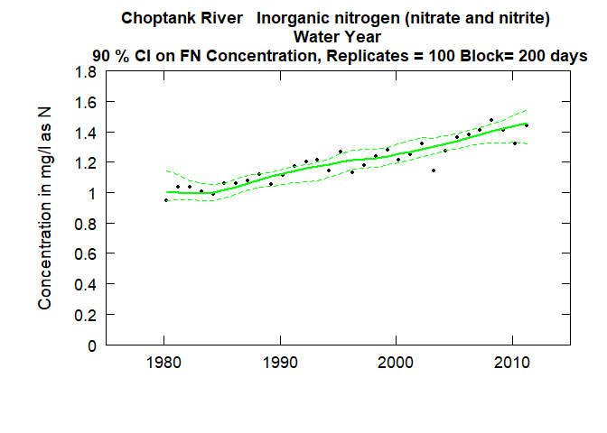

```r
eList <- Choptank_eList

CIAnnualResults <- Choptank_CIAnnualResults

plotConcHistBoot(eList, CIAnnualResults)
```

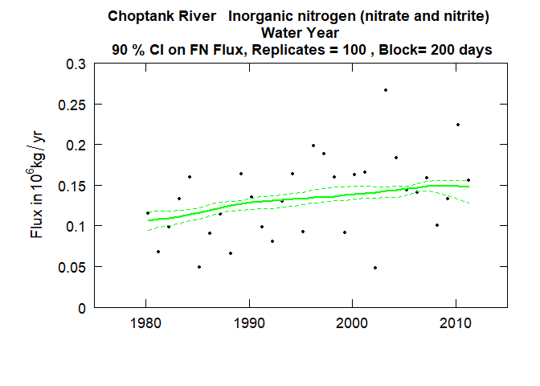

```r
plotFluxHistBoot(eList, CIAnnualResults)
```